# Practical solutions for working with electronic health records data

#### Introduction

The goal of this tutorial is to explore the structure of an electronic health records (EHR)-derived data set and some of the common challenges encountered in working with healthcare-derived data. We will also practice implementing some statistical methods introduced throughout the tutorial to address these issues. To do this we will use a synthetic data set simulated to mimic the structure of a real EHR-derived data set. **Please note that the data we will be working with are simulated and intended for instructional purposes only.** Real EHR data generally have access restrictions due to privacy/confidentiality issues and HIPAA protections. At the end of the course we will provide links for a few public access repositories that provide real EHR data. However, these generally do require a data use agreement and thus a few steps are involved in getting access.

The synthetic data we will be working with are based on the PEDSnet study of pediatric type 2 diabetes described in class. The data are divided into four files which can be downloaded from GitHub. The four files contain data from 9,930 patients age 10-20 years who had at least one outpatient encounter between 2001 and 2019. The four files can be linked using the variable patientid.

#### Encounter data

This data set includes one row per outpatient encounter.

```r
encounter = read.csv("https://raw.githubusercontent.com/rhubb/rhubb.github.io/master/data/encounter.csv", head=T)
```

> patientid: Patient ID

> servicedate: Date of the encounter

> age: Age in years

> race: Provider-reported patient race

> proc: CPT codes for procedure performed; codes 99211-99215 are for evaluation and management of established patients in an outpatient setting

> diag: ICD-9 (before 10/1/2015) or ICD-10 (on or after 10/1/2015) for primary diagnosis; a few diagnosis codes of interest are T2DM ICD-9 = “250.00”; T2DM ICD-10 = “E11.9”; T1DM ICD-9 = “250.01”; T1DM ICD-10 = “E10.9”; Depression ICD-9 = “296.2”,“296.9”,“296.3”,“300.4”; Depression ICD-10 = “F32.9”,“F41.8”,“F33.9”

> prov: CMS provider specialty code; a few provider codes of potential interest are General Practice = “1”, General Dermatology = “7”, Family practice = “8”, Internal Medicine = “11”, Neurology = “13”, Ophthalmology = “18”, Psychiatry = “26”, Pediatric Medicine = “37”, Endocrinology = “46”

#### Prescription medication data

This data set includes one row per prescription recorded on the date of an outpatient encounter included in the encounters file.

```r
meds = read.csv("https://raw.githubusercontent.com/rhubb/rhubb.github.io/master/data/meds.csv", head=T)
```

> patientid: Patient ID

> presdate: Date of the prescription

> drug: Drug class

#### Measures data

This data set includes one row per anthropometric or laboratory measurement recorded on the date of an outpatient encounter included in the encounters file.

```r
measures = read.csv("https://raw.githubusercontent.com/rhubb/rhubb.github.io/master/data/measures.csv", head=T)
```

> patientid: Patient ID

> servicedate: Date of measurement

> measurement: Numeric value of the measurement

> measuretype: Description of the laboratory or anthropometric test (height in cm, weight in kg, glucose in mg/dl, hemoglobin A1c (hba1c) in %, cholesterol (chol) in mg/dl)

#### Validation data

This data set includes one row per patient for 998 patients randomly selected for manual chart review to determine gold-standard type 2 diabetes status.

```r
validation = read.csv("https://raw.githubusercontent.com/rhubb/rhubb.github.io/master/data/validation.csv", head=T)
```

> patientid: Patient ID

> T2DMv: Type 2 diabetes status based on manual chart review (1 = T2DM, 0 = no evidence of T2DM)

#### Install R packages

- For these exercises you will need the [*rpart*](https://cran.r-project.org/web/packages/rpart/index.html), [*pROC*](https://cran.r-project.org/web/packages/pROC/index.html), [*boot*](https://cran.r-project.org/web/packages/boot/index.html), and [*gee*](https://cran.r-project.org/web/packages/gee/index.html) packages.
- If you have not already, please install these packages now.

```r
install.packages("rpart")
install.packages("pROC")
install.packages("boot")
install.packages("gee")
library(rpart)
library(pROC)
library(boot)
library(gee)
```

### Tutorial 1

A. **Data Quality Evaluation.** The first task in analysis of EHR data is data exploration and visualization to identify and resolve data errors. Focusing on the measures data set, we will carry out a descriptive analysis.

- Are there any observations that seem likely to be errors?
- What are some techniques we can use to identify errors?
- What are some options for handling possibly erroneous data points once they have been identified?

```r
## Use summary statistics and plots to investigate basic characteristics of the data

summary(measures)
```

```
##    patientid      servicedate         measurement     measuretype
##  Min.   :100172   Length:74398       Min.   : -0.10   Length:74398
##  1st Qu.:320683   Class :character   1st Qu.: 88.27   Class :character
##  Median :546440   Mode  :character   Median :131.50   Mode  :character
##  Mean   :545570                      Mean   :127.82
##  3rd Qu.:773212                      3rd Qu.:163.68
##  Max.   :999973                      Max.   :935.96
```

```r
# check types of measures available
unique(measures$measuretype)
```

```
## [1] "height"  "weight"  "hba1c"   "chol"    "glucose"
```

```r
# separate variables by measurement type
height <- measures[measures$measuretype == "height",-4]
names(height) <- c("patientid","servicedate","height")

weight <- measures[measures$measuretype == "weight",-4]
names(weight) <- c("patientid","servicedate","weight")

glucose <- measures[measures$measuretype == "glucose",-4]
names(glucose) <- c("patientid","servicedate","glucose")

hba1c <- measures[measures$measuretype == "hba1c",-4]
names(hba1c) <- c("patientid","servicedate","hba1c")

chol <- measures[measures$measuretype == "chol",-4]
names(chol) <- c("patientid","servicedate","chol")

# explore number of observations available per patient for each measurement type

summary(c(table(factor(height$patientid, levels = unique(encounter$patientid)))))
```

```
##    Min. 1st Qu.  Median    Mean 3rd Qu.    Max.
##    0.00    2.00    3.00    3.07    4.00   38.00
```

```r
summary(c(table(factor(weight$patientid, levels = unique(encounter$patientid)))))
```

```
##    Min. 1st Qu.  Median    Mean 3rd Qu.    Max.
##    0.00    2.00    3.00    3.07    4.00   38.00
```

```r
summary(c(table(factor(glucose$patientid, levels = unique(encounter$patientid)))))
```

```
##    Min. 1st Qu.  Median    Mean 3rd Qu.    Max.
##  0.0000  0.0000  0.0000  0.6432  1.0000 10.0000
```

```r
summary(c(table(factor(hba1c$patientid, levels = unique(encounter$patientid)))))
```

```
##    Min. 1st Qu.  Median    Mean 3rd Qu.    Max.
##  0.0000  0.0000  0.0000  0.4532  1.0000  6.0000
```

```r
summary(c(table(factor(chol$patientid, levels = unique(encounter$patientid)))))
```

```
##    Min. 1st Qu.  Median    Mean 3rd Qu.    Max.
##  0.0000  0.0000  0.0000  0.2561  0.0000  4.0000
```

```r
# number of children with no measures available

sum(c(table(factor(height$patientid, levels = unique(encounter$patientid)))) == 0)
```

```
## [1] 33
```

```r
sum(c(table(factor(weight$patientid, levels = unique(encounter$patientid)))) == 0)
```

```
## [1] 33
```

```r
sum(c(table(factor(glucose$patientid, levels = unique(encounter$patientid)))) == 0)
```

```
## [1] 5141
```

```r
sum(c(table(factor(hba1c$patientid, levels = unique(encounter$patientid)))) == 0)
```

```
## [1] 6235
```

```r
sum(c(table(factor(chol$patientid, levels = unique(encounter$patientid)))) == 0)
```

```
## [1] 7644
```

```r
# summarize distribution of variables across all patients, looking for values outside the plausible range

summary(height$height)
```

```
##    Min. 1st Qu.  Median    Mean 3rd Qu.    Max.
##   50.82  151.69  162.80  162.56  173.50  225.06
```

```r
summary(weight$weight)
```

```
##    Min. 1st Qu.  Median    Mean 3rd Qu.    Max.
##   -0.10   77.87   96.10   99.92  116.03  935.96
```

```r
summary(glucose$glucose)
```

```
##    Min. 1st Qu.  Median    Mean 3rd Qu.    Max.
##   28.06   79.03  100.75  115.97  128.67  481.01
```

```r
summary(hba1c$hba1c)
```

```
##    Min. 1st Qu.  Median    Mean 3rd Qu.    Max.
##   2.180   5.230   6.160   6.351   7.330  13.620
```

```r
summary(chol$chol)
```

```
##    Min. 1st Qu.  Median    Mean 3rd Qu.    Max.
##   41.31  187.36  328.48  290.60  373.36  519.34
```

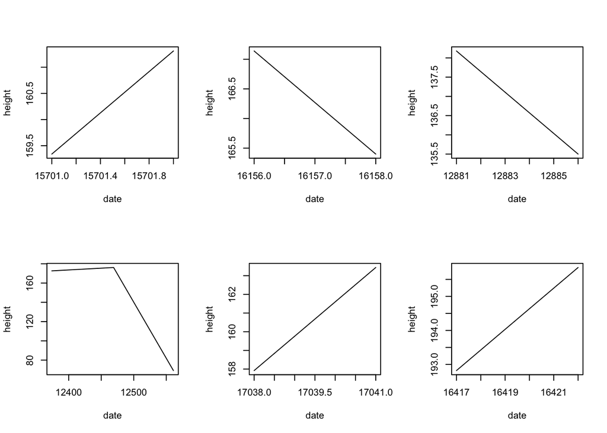

```r
# values that are clearly outside the plausible range can be eliminated, those that seem unlikely should be
# noted for discussion with clinical collaborators

# remove negative weights as clearly lying outside the plausible range

weight$weight <- ifelse(weight$weight < 0, NA, weight$weight)

# identify patients with extreme heights and weights

extreme.heights <- height$patientid[height$height < 100] # flag patients with height < 1 m
extreme.weights <- weight$patientid[weight$weight > 200] # flag patients with weight > 200 kg

# implausible patterns in longitudinal measurements provide an additional means of identifying data errors

height.s <- split(data.frame(height$servicedate,height$height),height$patientid)
weight.s <- split(data.frame(as.Date(weight$servicedate),weight$weight),weight$patientid)
glucose.s <- split(data.frame(as.Date(glucose$servicedate),glucose$glucose),glucose$patientid)
hba1c.s <- split(data.frame(as.Date(hba1c$servicedate),hba1c$hba1c),hba1c$patientid)

# summarize rate of change and within-patient variability

# function to estimate rate of change and residual variability for each child's data
longrate <- function(x){
  days <- as.numeric(as.Date(x[,1]))
  measure <- x[,2]
  mod <- lm(measure ~ days)
  rate <- mod$coef[2]
  residsd <- summary(mod)$sigma
  return(c(rate,residsd))
}

height.lm <- t(sapply(height.s,longrate))

# take a look at a few patients with implausible trajectories

height.change.ind <- which(abs(height.lm[,1]) > 0.5)
par(mfrow = c(2,3))
for (i in 1:6){
  plot(as.numeric(as.Date(height.s[[height.change.ind[i]]][,1])),height.s[[height.change.ind[i]]][,2], xlab = "date", ylab = "height", type = "l")
}
```

```r
# a few of these measures look very suspicious, as if one measurement is about 2.5 times the other
# take a closer look at an example case

height[height$patientid == names(height.change.ind[4]),]
```

```
##       patientid servicedate    height
## 22268    363685  2003-11-18 172.66000
## 22271    363685  2004-02-21 176.16000
## 22273    363685  2004-05-23  69.14254
```

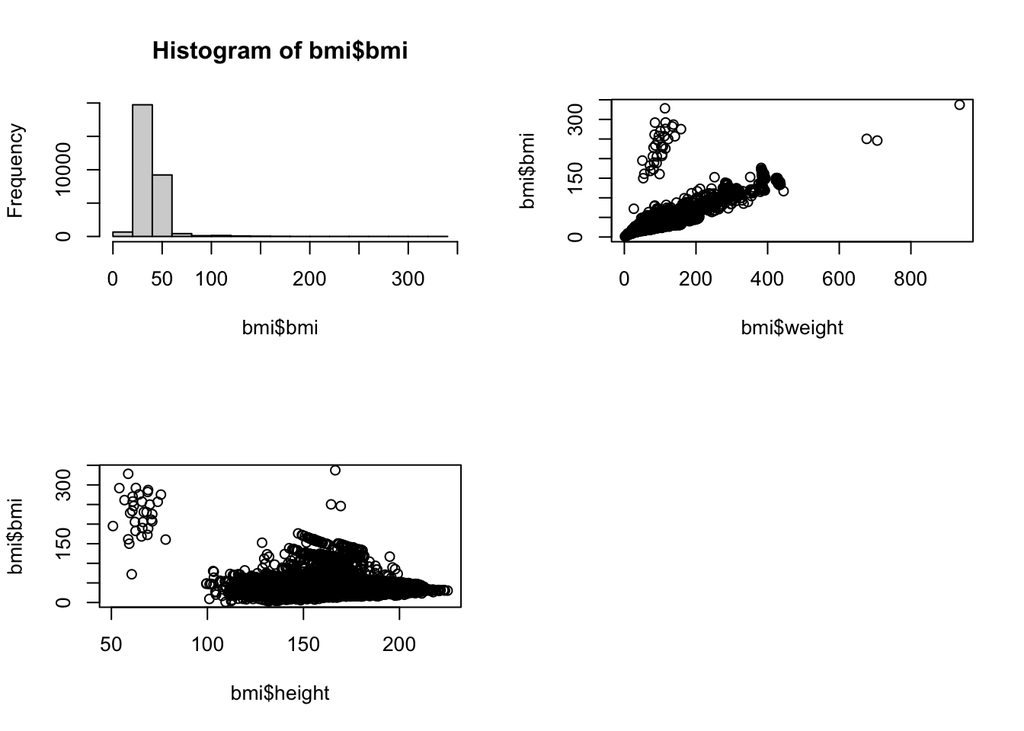

```r
# generate BMI and look for implausible values

height$iddate <- paste(height$patientid,height$servicedate)
weight$iddate <- paste(weight$patientid,weight$servicedate)
bmi <- merge(height,weight,by = "iddate") # merge height and weight data
bmi$bmi <- bmi$weight/(bmi$height/100)^2

par(mfrow = c(2,2))
hist(bmi$bmi)
plot(bmi$weight,bmi$bmi)
plot(bmi$height,bmi$bmi)

# unusual groupings in BMI plots suggest patients with wrong units for height or weight
# select a rule for eliminating these heights or weights

bmi$height <- ifelse(bmi$height < 100 & bmi$bmi > 100, bmi$height*2.54, bmi$height)
bmi$bmi <- bmi$weight/(bmi$height/100)^2

par(mfrow = c(2,2))
```

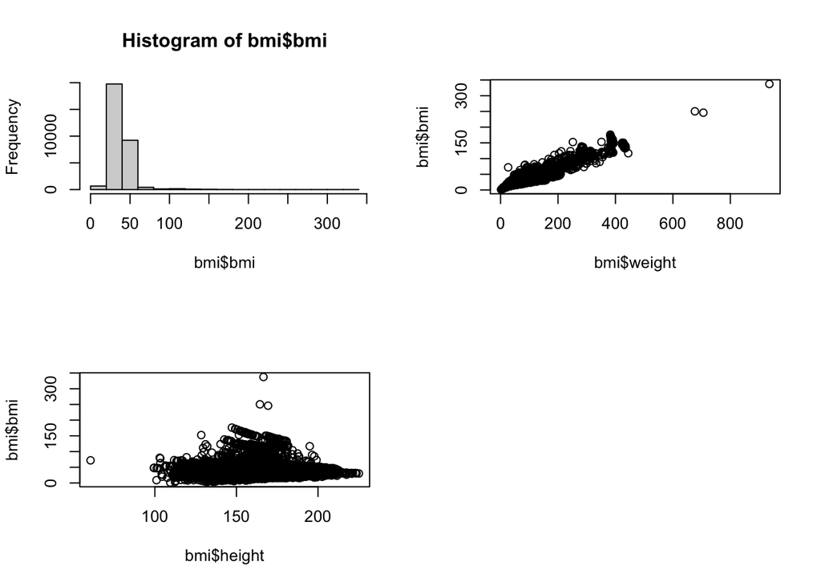

```r
hist(bmi$bmi)
plot(bmi$weight,bmi$bmi)
plot(bmi$height,bmi$bmi)
```

B. **Phenotype Extraction.** We will next explore a few alternative approaches to deriving a type 2 diabetes (T2DM) phenotype from this data set.

- Reduce the data to one observation per patient considering what data elements might be of use at the patient-level.
- Use the validation data to develop a prediction model for T2DM using logistic regression and CART.
- Apply the eMERGE T2DM rule to these data. How do the sensitivity, specificity, PPV, and NPV of these approaches compare?

```r
## Aggregate data to the patient level

# aggregate numeric measurements using the earliest, mean and maximum observed values

bmi$bmimean <- unsplit(sapply(split(bmi$bmi,bmi$patientid.x),mean,na.rm = T),bmi$patientid.x)
bmi$bmimax <- unsplit(sapply(split(bmi$bmi,bmi$patientid.x),max,na.rm = T),bmi$patientid.x)
bmi$firstbmi <- unsplit(sapply(split(bmi$bmi,bmi$patientid.x),function(x){x[1]}),bmi$patientid.x)

glucose$glucosemean <- unsplit(sapply(split(glucose$glucose,glucose$patientid),mean,na.rm = T),glucose$patientid)
glucose$glucosemax <- unsplit(sapply(split(glucose$glucose,glucose$patientid),max,na.rm = T),glucose$patientid)

hba1c$hba1cmean <- unsplit(sapply(split(hba1c$hba1c,hba1c$patientid),mean,na.rm = T),hba1c$patientid)
hba1c$hba1cmax <- unsplit(sapply(split(hba1c$hba1c,hba1c$patientid),max,na.rm = T),hba1c$patientid)

encounter$agemean <- unsplit(sapply(split(encounter$age,encounter$patientid),mean,na.rm = T),encounter$patientid)
encounter$firstage <- unsplit(sapply(split(encounter$age,encounter$patientid),min,na.rm = T),encounter$patientid)

# compute elapsed time from first visit to current visit and summarize cholesterol in first year of follow-up
encounter$basedate <- rep(encounter$servicedate[!duplicated(encounter$patientid)], time = c(table(encounter$patientid))) # date of first visit
encounter$elapsed <- as.Date(encounter$servicedate) - as.Date(encounter$basedate)
encounter$anyvisit1yr <- unsplit(sapply(split(encounter$elapsed,encounter$patientid), # binary indicator of any visit in first year of follow-up
                                   function(x){sum(x[x>0] <= 365) > 0}),encounter$patientid)
chol <- merge(chol,data.frame(patientid = encounter$patientid, basedate = encounter$basedate)[!duplicated(encounter$patientid),],
                              all.x = TRUE, all.y = FALSE)
chol$elapsed <- as.Date(chol$servicedate) - as.Date(chol$basedate)
chol$cholmean1yr <- unsplit(sapply(split(data.frame(chol = chol$chol, days = chol$elapsed),chol$patientid),
                                   function(x){mean(x$chol[x$days <= 365 & x$days > 0],na.rm = T)}),chol$patientid)

# look for any occurence of diabetes diagnosis codes, insulin, metformin,
# or visit to an endocrinologist within the period of interest
# T2DM ICD-9 = "250.00", T2DM ICD-10 = "E11.9", T1DM ICD-9 = "250.01", T1DM ICD-10 = "E10.9"
# Endocrinologist Medicare specialty code = 46

anycode <- function(x,code){
  code.present <- x %in% code
  return(sum(code.present)>0)
}

# Count number of occurences of code

sumcode <- function(x,code){
  code.present <- x %in% code
  return(sum(code.present))
}

# Determine whether metformin prescription precedes insulin prescription
# Returns 1 if only metformin prescribed or metformin prescribed before insulin
# otherwise returns 0

codeorder <- function(x){
  metdates <- as.Date(x$dates[x$drugs == "metformin"])
  insdates <- as.Date(x$dates[x$drugs == "insulin"])
  if (length(metdates) == 0) metfirst <- 0
  else if (length(metdates) > 0 & length(insdates) == 0) metfirst <- 1
  else if (length(metdates) == 0 & length(insdates) == 0) metfirst <- 0
  else metfirst <- suppressMessages(1*(min(metdates) < min(insdates)))
  return(metfirst)
}

# any T2DM code
encounter$T2DM <- unsplit(sapply(split(encounter$diag,encounter$patientid),anycode,code = c("250.00","E11.9")),encounter$patientid)

# number of T2DM codes
encounter$T2DMnum <- unsplit(sapply(split(encounter$diag,encounter$patientid),sumcode,code = c("250.00","E11.9")),encounter$patientid) # number of occurence of T2DM code

# any T1DM code
encounter$T1DM <- unsplit(sapply(split(encounter$diag,encounter$patientid),anycode,code = c("250.01","E10.9")),encounter$patientid)

# any visit to an endocrinologist
encounter$endo <- unsplit(sapply(split(encounter$prov,encounter$patientid),anycode,code = "46"),encounter$patientid)

# any depression diagnosis
encounter$dep <- unsplit(sapply(split(encounter$diag,encounter$patientid),anycode,code = c("296.2","296.9","296.3","300.4","F32.9","F41.8","F33.9")),encounter$patientid)

# any insulin prescription
meds$anyinsulin <- unsplit(sapply(split(meds$drug,meds$patientid),anycode,code = "insulin"),meds$patientid)

# any metformin prescription
meds$anymetformin <- unsplit(sapply(split(meds$drug,meds$patientid),anycode,code = "metformin"),meds$patientid)

# metformin prescription precedes insulin prescription
meds$metforminfirst <- unsplit(sapply(split(data.frame(dates=meds$presdate,drugs=meds$drug),
                       meds$patientid),codeorder),meds$patientid)


## Create merged dataset with one observation per patient and aggregate variables

encounter1 <- encounter[!duplicated(encounter$patientid),c("patientid","agemean","firstage","race","gender","T2DM","T1DM","endo","T2DMnum","dep","anyvisit1yr")]
bmi1 <- bmi[!duplicated(bmi$patientid.x),c("patientid.x","bmimean","bmimax","firstbmi")]
names(bmi1) <- c("patientid","bmimean","bmimax","firstbmi")
glucose1 <- glucose[!duplicated(glucose$patientid),c("patientid","glucosemean","glucosemax")]
hba1c1 <- hba1c[!duplicated(hba1c$patientid),c("patientid","hba1cmean","hba1cmax")]
chol1 <- chol[!duplicated(chol$patientid),c("patientid","cholmean1yr")]
meds1  <- meds[!duplicated(meds$patientid),c("patientid","anyinsulin","anymetformin","metforminfirst")]

data1 <- Reduce(function(x,y){merge(x,y, all = T)},list(encounter1,bmi1,glucose1,hba1c1,chol1,meds1,validation))

# create indicators for availability of any glucose or HbA1c measures

data1$anyglucose <- !is.na(data1$glucosemean)
data1$anyhba1c   <- !is.na(data1$hba1cmean)

# set insulin and metformin to false for patients with no medication data

data1$anyinsulin <- ifelse(is.na(data1$anyinsulin),FALSE,data1$anyinsulin)
data1$anymetformin <- ifelse(is.na(data1$anymetformin),FALSE,data1$anymetformin)

## Phenotyping models using gold standard labels from validation data set to construct prediction models for T2DM

## Logistic regression

mod.glm <- glm(T2DMv ~ T2DM + T1DM + bmimean + anyglucose + anyhba1c + anyinsulin + anymetformin, data = data1, family = "binomial")

# logistic regression-based phenotype
data1$T2DMglm <- predict(mod.glm, newdata = data1)

# evaluate performance of logistic regression phenotype
pred.glm <- na.omit(data.frame(pred = data1$T2DMglm,true = data1$T2DMv))
perf.glm <- roc(pred.glm$true, pred.glm$pred, auc = TRUE, print.auc = TRUE, show.thres = TRUE)
```

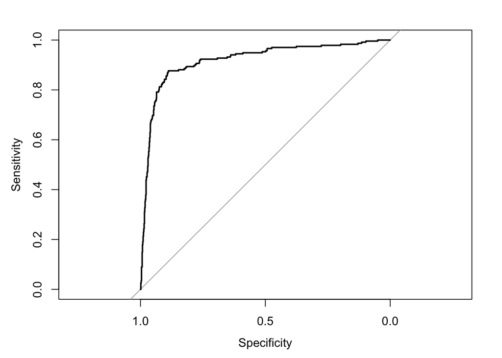

```r
plot(perf.glm)
```

```r
# Logistic regression AUC
perf.glm$auc
```

```
## Area under the curve: 0.9182
```

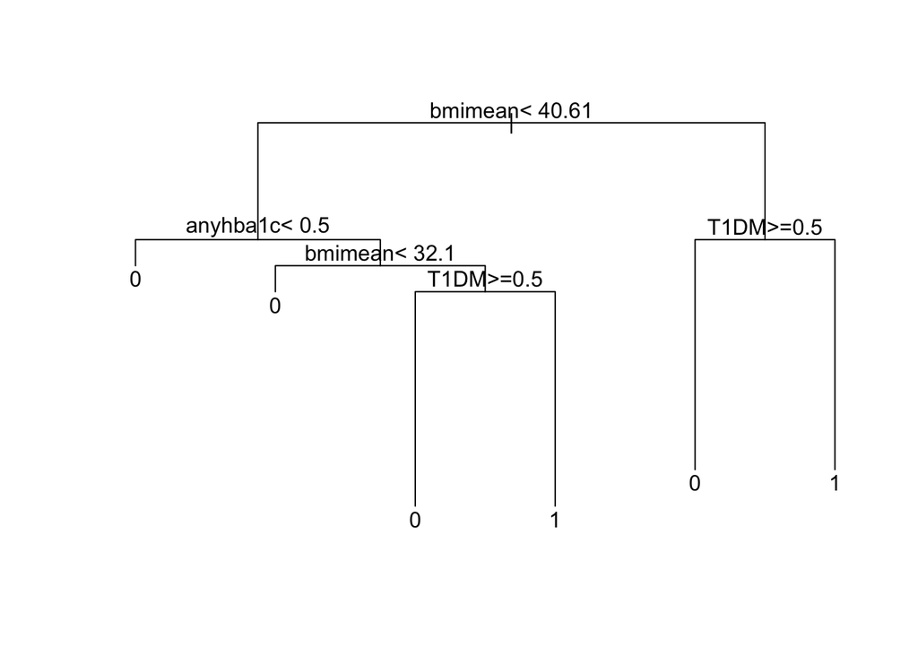

```r
## CART

set.seed(20190805)
mod.cart <- rpart(T2DMv ~ T2DM + T1DM  + bmimean + anyglucose + anyhba1c, data = data1, method = "class")
mod.pruned<- prune(mod.cart, cp= mod.cart$cptable[which.min(mod.cart$cptable[,"xerror"]),"CP"])

par(xpd = NA) # prevent text labels from being cut off
plot(mod.pruned)
text(mod.pruned)
```

```r
# predicted probabilities of T2DM based on CART
data1$T2DMcart <- predict(mod.pruned, newdata = data1, type = "prob")

# binary T2DM phenotype based on CART
data1$T2DMcart.class <- as.numeric(as.character(predict(mod.pruned, newdata = data1, type = "class")))

# evaluate performance of continuous CART phenotype
pred.cart <- na.omit(data.frame(pred = data1$T2DMcart[,2],true = data1$T2DMv))
perf.cart <- roc(pred.cart$true, pred.cart$pred, auc = TRUE, print.auc = TRUE, show.thres = TRUE)
```

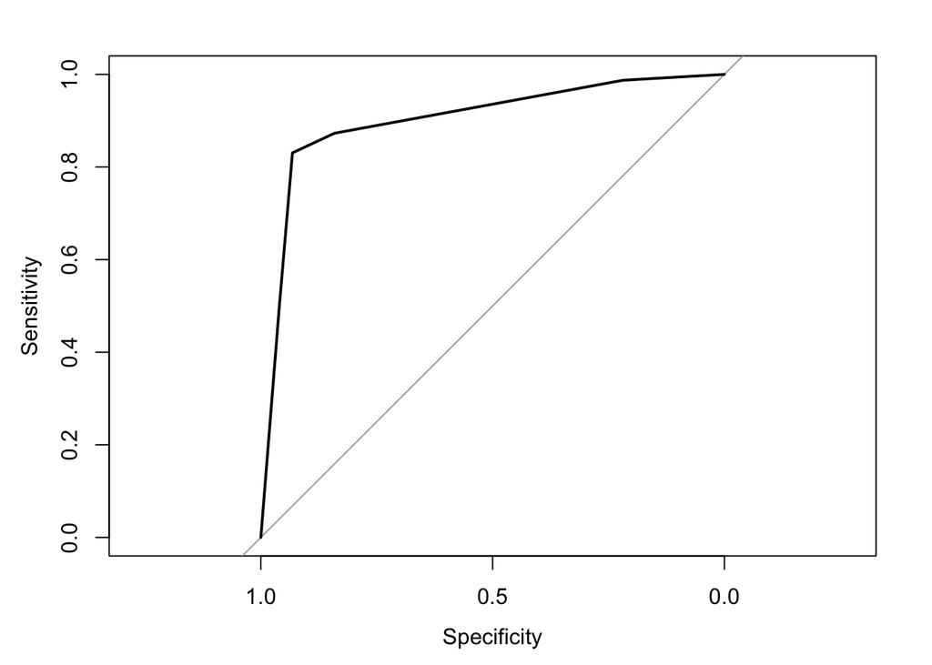

```r
par(xpd = FALSE)
plot(perf.cart)
```

```r
# CART AUC
perf.cart$auc
```

```
## Area under the curve: 0.9022
```

```r
## eMERGE T2DM rule

T2DM.rule <- function(x){
  if (x$T1DM ==1) T2DM <- 0
  else{
    if (x$T2DM ==1){
      if (x$anyinsulin == 1){
        if (x$anymetformin == 0){
          if (x$T2DMnum < 2){
            T2DM <- 0
          } else{
            T2DM <- 1
          }
        } else{
          if (x$metforminfirst == 0){
            T2DM <- 0
          } else{
            T2DM <- 1
          }
        }
      } else{
        if (x$anymetformin == 1){
          T2DM <- 1
        } else{
          if ((!is.na(x$glucosemax) & x$glucosemax > 200) | (!is.na(x$hba1cmax) & x$hba1cmax > 6.5)){
            T2DM <- 1
          } else{
            T2DM <- 0
          }
        }
      }
    } else{
      if (x$anymetformin == 0){
        T2DM <- 0
      } else{
        if ((!is.na(x$glucosemax) & x$glucosemax > 200) | (!is.na(x$hba1cmax) & x$hba1cmax > 6.5)){
          T2DM <- 1
        } else{
          T2DM <- 0
        }
      }
    }
  }
  return(T2DM)
}

data1$T2DMemerge <- unsplit(sapply(split(data1,data1$patientid),T2DM.rule),data1$patientid)

# eMERGE specificity
1-mean(data1$T2DMemerge[data1$T2DMv == 0 & !is.na(data1$T2DMv)])
```

```
## [1] 0.9685039
```

```r
# eMERGE sensitivity
mean(data1$T2DMemerge[data1$T2DMv == 1 & !is.na(data1$T2DMv)])
```

```
## [1] 0.1059322
```

```r
# eMERGE PPV
mean(data1$T2DMv[data1$T2DMemerge == 1],na.rm = T)
```

```
## [1] 0.5102041
```

```r
# eMERGE NPV
1 - mean(data1$T2DMv[data1$T2DMemerge == 0],na.rm = T)
```

```
## [1] 0.7776607
```

C. **Missing Data.** Next we will explore missing data in an EHR-derived data set. Suppose we want to use our T2DM phenotype from exercise 2 to explore the relationship between total cholesterol and T2DM diagnosis.

- Using mean cholesterol in the one year period after baseline as our exposure measure, how much missingness is there?
- Is missingness related to any other factors in the data set?
- Use IPW with a single module or multiple modules to account for missingness in your analysis of the association between total cholesterol and T2DM.

```r
## For most real examples we would want to define our exposure (cholesterol) in a window around
## cohort entry. For this toy example we will use the one year period after cohort entry.

# Percent with no cholesterol data in first year of follow-up
mean(is.na(data1$cholmean1yr))
```

```
## [1] 0.9396777
```

```r
# Percent with no visit in first year of follow-up
mean(data1$anyvisit1yr==0)
```

```
## [1] 0.4663646
```

```r
# Look for factors associated with missing cholesterol
data1$misschol <- is.na(data1$cholmean1yr)
misschol.mod <- glm(misschol ~ firstage + race + gender + firstbmi, data = data1, family = binomial)
summary(misschol.mod)
```

```
##
## Call:
## glm(formula = misschol ~ firstage + race + gender + firstbmi,
##     family = binomial, data = data1)
##
## Deviance Residuals:
##     Min       1Q   Median       3Q      Max
## -2.6086   0.3183   0.3414   0.3680   1.3357
##
## Coefficients:
##               Estimate Std. Error z value Pr(>|z|)
## (Intercept)   3.764876   0.413963   9.095  < 2e-16 ***
## firstage      0.003090   0.018973   0.163    0.871
## raceBlack    -0.261875   0.282834  -0.926    0.355
## raceHispanic -0.491904   0.312672  -1.573    0.116
## raceOther    -0.291877   0.358445  -0.814    0.415
## raceUnknown  -0.541662   0.347241  -1.560    0.119
## raceWhite    -0.241763   0.281146  -0.860    0.390
## genderMale    0.027737   0.084723   0.327    0.743
## firstbmi     -0.022153   0.003371  -6.572 4.96e-11 ***
## ---
## Signif. codes:  0 '***' 0.001 '**' 0.01 '*' 0.05 '.' 0.1 ' ' 1
##
## (Dispersion parameter for binomial family taken to be 1)
##
##     Null deviance: 4520.9  on 9895  degrees of freedom
## Residual deviance: 4476.5  on 9887  degrees of freedom
##   (34 observations deleted due to missingness)
## AIC: 4494.5
##
## Number of Fisher Scoring iterations: 5
```

```r
# probability of having an observed cholesterol measure based on single stage model
data1$pobschol1[!is.na(data1$firstbmi)] <- 1-predict(misschol.mod, type = "response", data = data1)

# Estimate probability of observed cholesterol using a two stage model
# first estimate probability of having any encounter within 1 yr
anyvisit.mod <- glm(anyvisit1yr ~ firstage + race + gender + firstbmi, data = data1, family = binomial)
summary(anyvisit.mod)
```

```
##
## Call:
## glm(formula = anyvisit1yr ~ firstage + race + gender + firstbmi,
##     family = binomial, data = data1)
##
## Deviance Residuals:
##     Min       1Q   Median       3Q      Max
## -2.9167  -1.1907   0.8941   1.1173   1.6006
##
## Coefficients:
##                Estimate Std. Error z value Pr(>|z|)
## (Intercept)  -1.0992497  0.1974460  -5.567 2.59e-08 ***
## firstage      0.0101622  0.0091283   1.113    0.266
## raceBlack    -0.1367995  0.1229533  -1.113    0.266
## raceHispanic -0.0815880  0.1429286  -0.571    0.568
## raceOther    -0.0007502  0.1624535  -0.005    0.996
## raceUnknown  -0.1980773  0.1656507  -1.196    0.232
## raceWhite    -0.1790432  0.1219779  -1.468    0.142
## genderMale    0.0255804  0.0409514   0.625    0.532
## firstbmi      0.0350847  0.0022831  15.367  < 2e-16 ***
## ---
## Signif. codes:  0 '***' 0.001 '**' 0.01 '*' 0.05 '.' 0.1 ' ' 1
##
## (Dispersion parameter for binomial family taken to be 1)
##
##     Null deviance: 13670  on 9895  degrees of freedom
## Residual deviance: 13403  on 9887  degrees of freedom
##   (34 observations deleted due to missingness)
## AIC: 13421
##
## Number of Fisher Scoring iterations: 4
```

```r
# probability of having an encounter
data1$pvisit1yr[!is.na(data1$firstbmi)] <- predict(anyvisit.mod, type = "response")

# next estimate probability of having cholesterol measurement given an encounter was observed
misschol.mod2 <- glm(misschol ~ firstage + race + gender + firstbmi, data = data1[data1$anyvisit1yr == 1,], family = binomial)
summary(misschol.mod2)
```

```
##
## Call:
## glm(formula = misschol ~ firstage + race + gender + firstbmi,
##     family = binomial, data = data1[data1$anyvisit1yr == 1, ])
##
## Deviance Residuals:
##     Min       1Q   Median       3Q      Max
## -2.3169   0.4581   0.4799   0.5011   0.9778
##
## Coefficients:
##               Estimate Std. Error z value Pr(>|z|)
## (Intercept)   2.680455   0.424625   6.313 2.75e-10 ***
## firstage      0.009305   0.019503   0.477  0.63329
## raceBlack    -0.340464   0.287974  -1.182  0.23710
## raceHispanic -0.549516   0.319281  -1.721  0.08523 .
## raceOther    -0.303867   0.365839  -0.831  0.40620
## raceUnknown  -0.658384   0.356249  -1.848  0.06459 .
## raceWhite    -0.335416   0.286264  -1.172  0.24132
## genderMale    0.034294   0.087102   0.394  0.69379
## firstbmi     -0.011132   0.003749  -2.970  0.00298 **
## ---
## Signif. codes:  0 '***' 0.001 '**' 0.01 '*' 0.05 '.' 0.1 ' ' 1
##
## (Dispersion parameter for binomial family taken to be 1)
##
##     Null deviance: 3738.3  on 5294  degrees of freedom
## Residual deviance: 3723.6  on 5286  degrees of freedom
##   (4 observations deleted due to missingness)
## AIC: 3741.6
##
## Number of Fisher Scoring iterations: 4
```

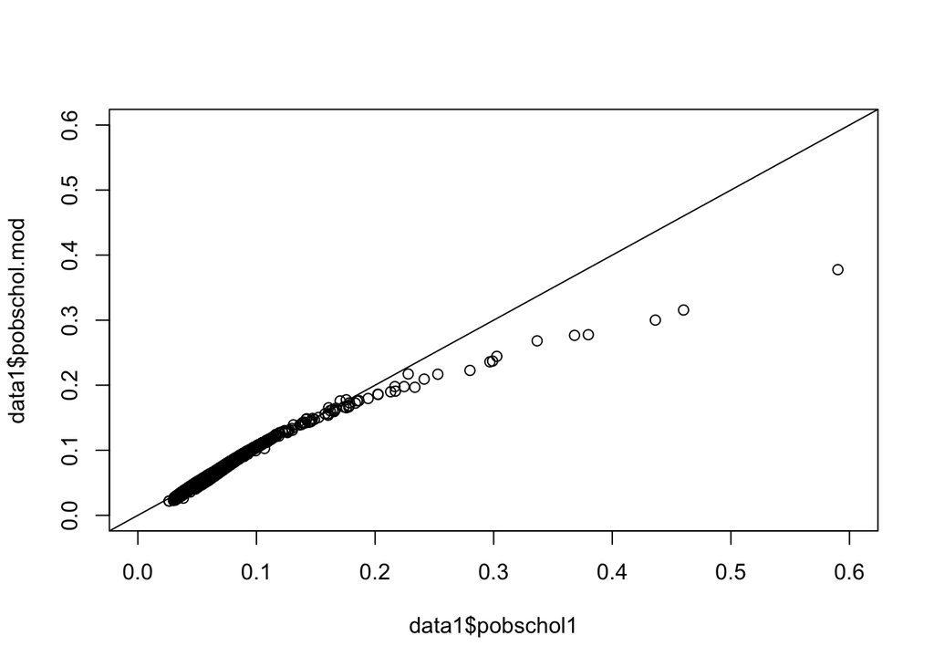

```r
# probability of having a choletserol measure given an encounter occurred in first year
data1$pobschol2[!is.na(data1$firstbmi)] <- 1-predict(misschol.mod2, type = "response", newdata = data1[!is.na(data1$firstbmi),])

# create combined probability of having an observed cholesterol value using the two stage model
data1$pobschol.mod <- data1$pvisit1yr*data1$pobschol2

## Compare one module and two module probabilities of being observed
plot(data1$pobschol1, data1$pobschol.mod, xlim = c(0,0.6), ylim = c(0,0.6))
abline(0,1)
```

```r
## Fit regression models using IPW to account for missingness in cholesterol

# Model using 1 step weights
data1$w1 <- 1/data1$pobschol1 # inverse probability of observed cholesterol value
data1$w1[!is.na(data1$cholmean1yr)] <- sum(!is.na(data1$cholmean1yr))*data1$w1[!is.na(data1$cholmean1yr)]/
  sum(data1$w1[!is.na(data1$cholmean1yr)],na.rm = T) # normalize weights to maintain sample size
chol.mod1 <- glm(T2DMcart.class~ firstage + factor(race) + gender + cholmean1yr, data = data1, weights = w1, family = "binomial")
summary(chol.mod1)
```

```
##
## Call:
## glm(formula = T2DMcart.class ~ firstage + factor(race) + gender +
##     cholmean1yr, family = "binomial", data = data1, weights = w1)
##
## Deviance Residuals:
##     Min       1Q   Median       3Q      Max
## -1.1148  -0.7555  -0.6699   1.0983   2.0955
##
## Coefficients:
##                        Estimate Std. Error z value Pr(>|z|)
## (Intercept)          -1.2746165  0.8556117  -1.490    0.136
## firstage              0.0038109  0.0431655   0.088    0.930
## factor(race)Black    -0.2035116  0.5723364  -0.356    0.722
## factor(race)Hispanic  0.1539734  0.6576392   0.234    0.815
## factor(race)Other    -0.6631391  0.8377485  -0.792    0.429
## factor(race)Unknown   0.2284052  0.7603756   0.300    0.764
## factor(race)White    -0.1350680  0.5673360  -0.238    0.812
## genderMale           -0.3191005  0.1998604  -1.597    0.110
## cholmean1yr           0.0008587  0.0009821   0.874    0.382
##
## (Dispersion parameter for binomial family taken to be 1)
##
##     Null deviance: 631.37  on 598  degrees of freedom
## Residual deviance: 625.82  on 590  degrees of freedom
##   (9331 observations deleted due to missingness)
## AIC: 681.46
##
## Number of Fisher Scoring iterations: 4
```

```r
# Model using 2 step weights
data1$w.mod <- 1/data1$pobschol.mod # inverse probability of observed cholesterol value
data1$w.mod[!is.na(data1$cholmean1yr)] <- sum(!is.na(data1$cholmean1yr))*data1$w.mod[!is.na(data1$cholmean1yr)]/
  sum(data1$w.mod[!is.na(data1$cholmean1yr)],na.rm = T) # normalize weights to maintain sample size
chol.mod2 <- glm(T2DMcart.class~ firstage + factor(race) + gender + cholmean1yr, data = data1, weights = w.mod, family = "binomial")
summary(chol.mod2)
```

```
##
## Call:
## glm(formula = T2DMcart.class ~ firstage + factor(race) + gender +
##     cholmean1yr, family = "binomial", data = data1, weights = w.mod)
##
## Deviance Residuals:
##     Min       1Q   Median       3Q      Max
## -1.1421  -0.7446  -0.6482   1.0964   2.0962
##
## Coefficients:
##                        Estimate Std. Error z value Pr(>|z|)
## (Intercept)          -1.3138156  0.8681574  -1.513    0.130
## firstage              0.0031205  0.0436305   0.072    0.943
## factor(race)Black    -0.2143712  0.5805502  -0.369    0.712
## factor(race)Hispanic  0.1564817  0.6659983   0.235    0.814
## factor(race)Other    -0.6350569  0.8454768  -0.751    0.453
## factor(race)Unknown   0.2229163  0.7703259   0.289    0.772
## factor(race)White    -0.1415255  0.5753657  -0.246    0.806
## genderMale           -0.3085058  0.2023348  -1.525    0.127
## cholmean1yr           0.0008794  0.0009956   0.883    0.377
##
## (Dispersion parameter for binomial family taken to be 1)
##
##     Null deviance: 619.89  on 598  degrees of freedom
## Residual deviance: 614.65  on 590  degrees of freedom
##   (9331 observations deleted due to missingness)
## AIC: 691.39
##
## Number of Fisher Scoring iterations: 4
```

```r
# Compare parameter estimates from the two models
cbind(chol.mod1$coef,chol.mod2$coef)
```

```
##                              [,1]          [,2]
## (Intercept)          -1.274616496 -1.3138156038
## firstage              0.003810935  0.0031204762
## factor(race)Black    -0.203511596 -0.2143712424
## factor(race)Hispanic  0.153973378  0.1564817137
## factor(race)Other    -0.663139085 -0.6350569362
## factor(race)Unknown   0.228405244  0.2229162941
## factor(race)White    -0.135067988 -0.1415254698
## genderMale           -0.319100516 -0.3085058309
## cholmean1yr           0.000858671  0.0008794016
```